# Model that can predict the progression of diabetes

```python
import pandas as pd
import matplotlib.pyplot as plt
import seaborn as sns
from sklearn import datasets
from sklearn import linear_model
from sklearn.metrics import mean_squared_error, mean_absolute_error
```

## 1. Obtaining the Data

Source: Downloaded from [Dataset scikit](https://scikit-learn.org/stable/modules/generated/sklearn.datasets.load_diabetes.html#sklearn.datasets.load_diabetes)

```python
diabetes_data = datasets.load_diabetes(as_frame=True)  # Cargar el dataset como un DataFrame para facilitar la EDA
data = diabetes_data.frame

data
```

|  | age | sex | bmi | bp | s1 | s2 | s3 | s4 | s5 | s6 | target |
| --- | --- | --- | --- | --- | --- | --- | --- | --- | --- | --- | --- |
| 0 | 0.038076 | 0.050680 | 0.061696 | 0.021872 | -0.044223 | -0.034821 | -0.043401 | -0.002592 | 0.019907 | -0.017646 | 151.0 |
| 1 | -0.001882 | -0.044642 | -0.051474 | -0.026328 | -0.008449 | -0.019163 | 0.074412 | -0.039493 | -0.068332 | -0.092204 | 75.0 |
| 2 | 0.085299 | 0.050680 | 0.044451 | -0.005670 | -0.045599 | -0.034194 | -0.032356 | -0.002592 | 0.002861 | -0.025930 | 141.0 |
| 3 | -0.089063 | -0.044642 | -0.011595 | -0.036656 | 0.012191 | 0.024991 | -0.036038 | 0.034309 | 0.022688 | -0.009362 | 206.0 |
| 4 | 0.005383 | -0.044642 | -0.036385 | 0.021872 | 0.003935 | 0.015596 | 0.008142 | -0.002592 | -0.031988 | -0.046641 | 135.0 |
| ... | ... | ... | ... | ... | ... | ... | ... | ... | ... | ... | ... |
| 437 | 0.041708 | 0.050680 | 0.019662 | 0.059744 | -0.005697 | -0.002566 | -0.028674 | -0.002592 | 0.031193 | 0.007207 | 178.0 |
| 438 | -0.005515 | 0.050680 | -0.015906 | -0.067642 | 0.049341 | 0.079165 | -0.028674 | 0.034309 | -0.018114 | 0.044485 | 104.0 |
| 439 | 0.041708 | 0.050680 | -0.015906 | 0.017293 | -0.037344 | -0.013840 | -0.024993 | -0.011080 | -0.046883 | 0.015491 | 132.0 |
| 440 | -0.045472 | -0.044642 | 0.039062 | 0.001215 | 0.016318 | 0.015283 | -0.028674 | 0.026560 | 0.044529 | -0.025930 | 220.0 |
| 441 | -0.045472 | -0.044642 | -0.073030 | -0.081413 | 0.083740 | 0.027809 | 0.173816 | -0.039493 | -0.004222 | 0.003064 | 57.0 |

442 rows × 11 columns

## 2. Frame the Problem

The goal of the project is to build a model that can predict the progression of diabetes one year after the initial values of various characteristics. The prediction will help doctors identify patients who will be at risk in one year. In this way, treatments and clinical decisions can be improved.

- The dependent variable is the “target” column, which is the progression of diabetes in patients one year after the starting point. It is the variable that is to be predicted.
- The independent variables are various characteristics such as age, sex, body mass index (BMI), blood pressure, and blood measurements, these are the initial values that will serve as input to the model to predict the progression of the disease.

## 3. Data Exploration - EDA

### 3.1 Descriptive statistics:

```python
data.describe()
```

|  | age | sex | bmi | bp | s1 | s2 | s3 | s4 | s5 | s6 | target |
| --- | --- | --- | --- | --- | --- | --- | --- | --- | --- | --- | --- |
| count | 4.420000e+02 | 4.420000e+02 | 4.420000e+02 | 4.420000e+02 | 4.420000e+02 | 4.420000e+02 | 4.420000e+02 | 4.420000e+02 | 4.420000e+02 | 4.420000e+02 | 442.000000 |
| mean | -2.511817e-19 | 1.230790e-17 | -2.245564e-16 | -4.797570e-17 | -1.381499e-17 | 3.918434e-17 | -5.777179e-18 | -9.042540e-18 | 9.293722e-17 | 1.130318e-17 | 152.133484 |
| std | 4.761905e-02 | 4.761905e-02 | 4.761905e-02 | 4.761905e-02 | 4.761905e-02 | 4.761905e-02 | 4.761905e-02 | 4.761905e-02 | 4.761905e-02 | 4.761905e-02 | 77.093005 |
| min | -1.072256e-01 | -4.464164e-02 | -9.027530e-02 | -1.123988e-01 | -1.267807e-01 | -1.156131e-01 | -1.023071e-01 | -7.639450e-02 | -1.260971e-01 | -1.377672e-01 | 25.000000 |
| 25% | -3.729927e-02 | -4.464164e-02 | -3.422907e-02 | -3.665608e-02 | -3.424784e-02 | -3.035840e-02 | -3.511716e-02 | -3.949338e-02 | -3.324559e-02 | -3.317903e-02 | 87.000000 |
| 50% | 5.383060e-03 | -4.464164e-02 | -7.283766e-03 | -5.670422e-03 | -4.320866e-03 | -3.819065e-03 | -6.584468e-03 | -2.592262e-03 | -1.947171e-03 | -1.077698e-03 | 140.500000 |
| 75% | 3.807591e-02 | 5.068012e-02 | 3.124802e-02 | 3.564379e-02 | 2.835801e-02 | 2.984439e-02 | 2.931150e-02 | 3.430886e-02 | 3.243232e-02 | 2.791705e-02 | 211.500000 |
| max | 1.107267e-01 | 5.068012e-02 | 1.705552e-01 | 1.320436e-01 | 1.539137e-01 | 1.987880e-01 | 1.811791e-01 | 1.852344e-01 | 1.335973e-01 | 1.356118e-01 | 346.000000 |

```
array([[<Axes: title={'center': 'age'}>, <Axes: title={'center': 'sex'}>,
        <Axes: title={'center': 'bmi'}>],
       [<Axes: title={'center': 'bp'}>, <Axes: title={'center': 's1'}>,
        <Axes: title={'center': 's2'}>],
       [<Axes: title={'center': 's3'}>, <Axes: title={'center': 's4'}>,
        <Axes: title={'center': 's5'}>],
       [<Axes: title={'center': 's6'}>,
        <Axes: title={'center': 'target'}>, <Axes: >]], dtype=object)
```

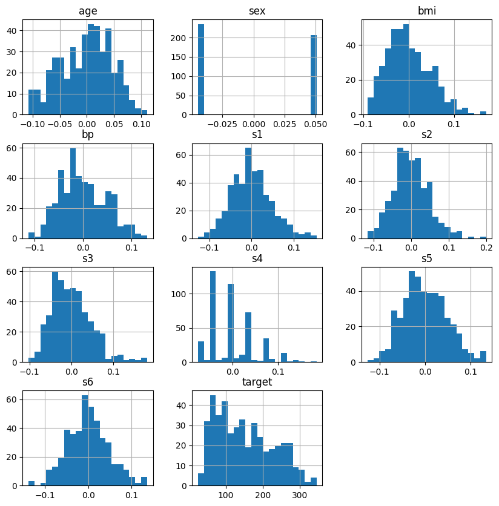

```python
data.hist(bins=20, figsize=(10,10))
```

### 3.2. Scatter plots

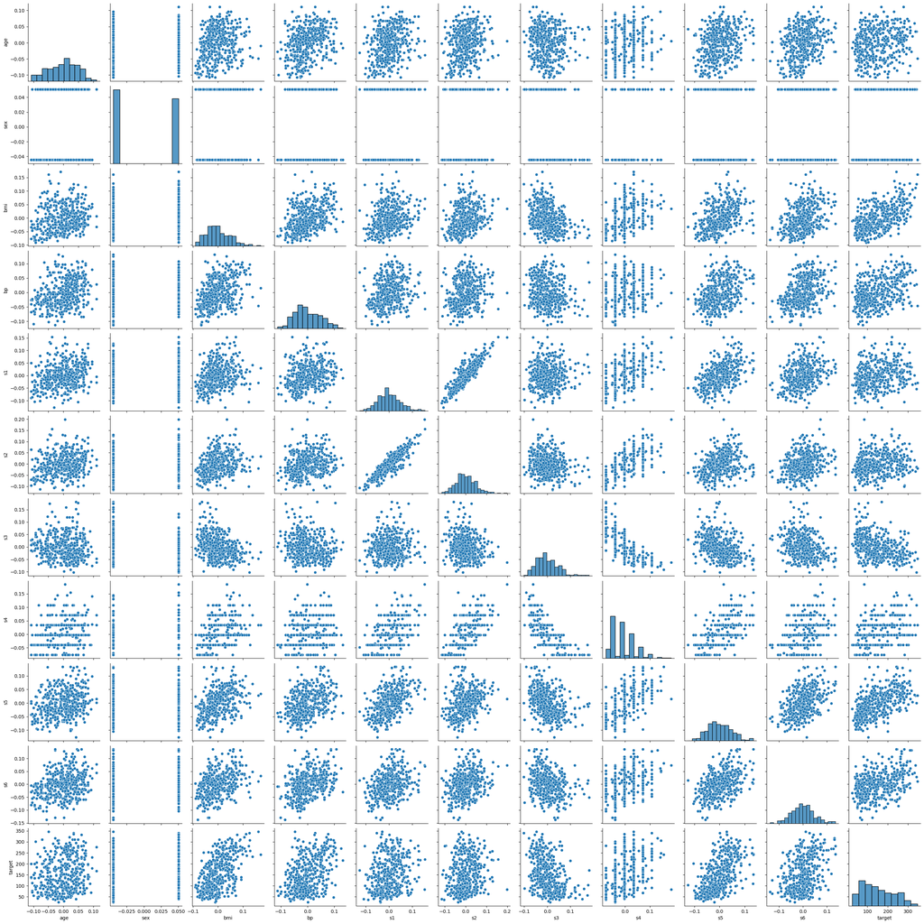

```python
sns.pairplot(data)
plt.show()
```

After analyzing the scatter diagrams, it is seen that the characteristics of BMI and S5 sample have a positive correlation with target that could be useful variables for prediction.

### 3.3 Correlation - Correlation matrix

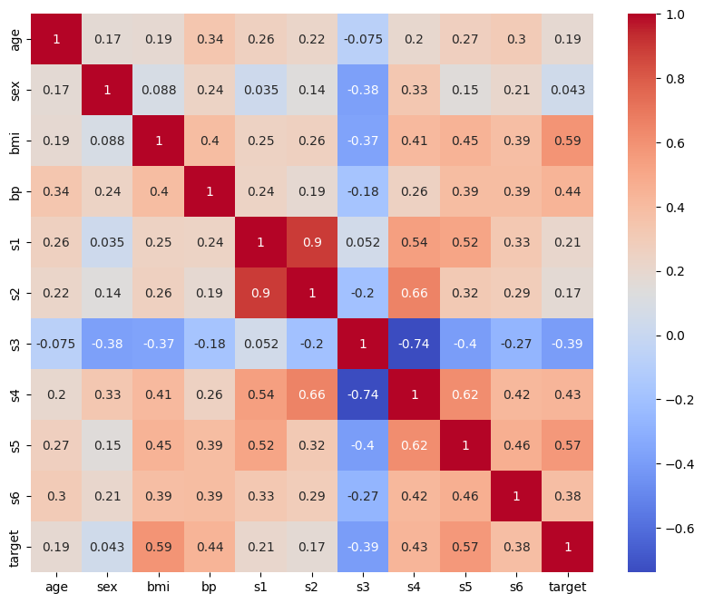

```python
import seaborn as sns
import matplotlib.pyplot as plt

plt.figure(figsize=(10, 8))
sns.heatmap(data.corr(), annot=True, cmap="coolwarm")
plt.show()
```

- In the case of target (disease progression), some features have higher correlations: bmi (body mass index) has a positive correlation of 0.59, indicating a moderately strong relationship with diabetes progression.
  - s5 also shows a significant positive correlation (0.57).
  - bp (blood pressure) and s6 have weaker correlations, but are still positive (0.44 and 0.38, respectively).
- Variables such as sex and s3 have very low or negative correlations with target, suggesting that they may not be as useful for predicting disease progression.

## 4. Data cleansing:

```python
data.isnull().sum()
```

```
age       0
sex       0
bmi       0
bp        0
s1        0
s2        0
s3        0
s4        0
s5        0
s6        0
target    0
dtype: int64
```

## 5. Splitting the dataset:

```
The data is divided into: training set (75%), validation (10%) and test (15%):
```

```python
from sklearn.model_selection import train_test_split

X = data.drop(columns=['target'])
y = data['target']

X_train, X_temp, y_train, y_temp = train_test_split(X, y, test_size=0.25, random_state=42)
X_val, X_test, y_val, y_test = train_test_split(X_temp, y_temp, test_size=0.6, random_state=42)
```

## 6. Univariate polynomial regression models (with BMI):

```python
from sklearn.preprocessing import PolynomialFeatures
from sklearn.linear_model import LinearRegression
from sklearn.metrics import mean_squared_error, r2_score, mean_absolute_error

X_train_bmi = X_train[['bmi']]
X_val_bmi = X_val[['bmi']]

models = {}
for degree in range(6):
    poly_features = PolynomialFeatures(degree=degree)
    X_train_poly = poly_features.fit_transform(X_train_bmi)
    model = LinearRegression().fit(X_train_poly, y_train)
    models[degree] = model
```

## 7. Evaluation

```python
import pandas as pd

results = []
for degree, model in models.items():
    X_val_poly = PolynomialFeatures(degree=degree).fit_transform(X_val_bmi)
    y_pred = model.predict(X_val_poly)

    r2 = r2_score(y_val, y_pred)
    mae = mean_absolute_error(y_val, y_pred)
    mape = (abs((y_val - y_pred) / y_val)).mean() * 100

    results.append({'Degree': degree, 'R2': r2, 'MAE': mae, 'MAPE': mape})

results_df = pd.DataFrame(results)
display(results_df)
```

|  | Degree | R2 | MAE | MAPE |
| --- | --- | --- | --- | --- |
| 0 | 0 | -0.106957 | 66.057059 | 71.263880 |
| 1 | 1 | 0.331264 | 47.208472 | 47.060009 |
| 2 | 2 | 0.331631 | 47.213700 | 47.239667 |
| 3 | 3 | 0.331638 | 47.185414 | 47.222673 |
| 4 | 4 | 0.340758 | 46.090118 | 46.050330 |
| 5 | 5 | 0.349881 | 45.462121 | 45.175275 |

## 8. Identify the best model:

Analyzing the results of R2, MAE and MAPE of the 6 models with degrees from 0 to 5, we can see: - In the case of the R2 metric, as the degree increases, the value of R2 increases, approaching the value of 1, reaching a maximum of approximately 0.3499 at degree 5. This indicates that the polynomial models with higher degrees better explain the variation of the dependent variable. The 0.3499 indicates that the model has a moderate capacity to explain the variability.

## 9. Run the chosen model on the test set and provide results (R-Squared, MAPE, MAE)

```python
best_degree = results_df['R2'].idxmax()
best_model = models[best_degree]
X_test_poly = PolynomialFeatures(degree=best_degree).fit_transform(X_test[['bmi']])
y_test_pred = best_model.predict(X_test_poly)

r2_test = r2_score(y_test, y_test_pred)
mae_test = mean_absolute_error(y_test, y_test_pred)
mape_test = (abs((y_test - y_test_pred) / y_test)).mean() * 100
print(f"R2: {r2_test}, MAE: {mae_test}, MAPE: {mape_test}")
```

```
R2: 0.266696584495308, MAE: 51.750257092773964, MAPE: 43.02671323305442
```

The model has limited ability to predict the target variable in the test data. Low R² suggests that the model does not explain the variation in the target variable well, and relatively high errors in MAE and MAPE indicate that the predictions are not very accurate. This could be due to the nature of the problem, the need for a more complex model, or the lack of other important features in the dataset.

## 10 Plot a graph of the train, validation and test data points, and the fit of the chosen model over each of them

[figure not shown]

```python
import numpy as np
import matplotlib.pyplot as plt
from sklearn.preprocessing import PolynomialFeatures

plt.scatter(X_train['bmi'], y_train, color='blue', label='Train')
plt.scatter(X_val['bmi'], y_val, color='green', label='Validation')
plt.scatter(X_test['bmi'], y_test, color='red', label='Test')

X_range = np.linspace(X_train['bmi'].min(), X_train['bmi'].max(), 100)
X_range_poly = PolynomialFeatures(degree=best_degree).fit_transform(X_range.reshape(-1, 1))
y_range_pred = best_model.predict(X_range_poly)

plt.plot(X_range, y_range_pred, color='black', label='Model Fit')

plt.xlabel('BMI (Body Mass Index)')
plt.ylabel('Target (Diabetes Progression)')
plt.legend()
plt.title('Fitting the Polynomial Regression Model for BMI')
plt.show()
```

## 11. Write down the equation of the best model

```python
# Get the coefficients and intercept of the model
coef = best_model.coef_
intercept = best_model.intercept_

# Print the model equation
equation = f"y = {intercept:.2f}"
for i in range(1, best_degree + 1):
    equation += f" + {coef[i]:.2f}*x^{i}"

print(f"El modelo de regresión polinómica de grado {best_degree} es:\n{equation}")
```

```
El modelo de regresión polinómica de grado 5 es:
y = 153.65 + 1059.89*x^1 + -3824.15*x^2 + -16770.23*x^3 + 753722.52*x^4 + -2993716.57*x^5
```

## 12. Calculate the expected diabetes progression for a BMI value

```python
bmi_value = 0.06
poly_features = PolynomialFeatures(degree=best_degree)
bmi_poly = poly_features.fit_transform([[bmi_value]])
prediction = best_model.predict(bmi_poly)
print(f"Predicted disease progression for BMI {bmi_value}: {prediction}")


bmi_value = 4.00
poly_features = PolynomialFeatures(degree=best_degree)
bmi_poly = poly_features.fit_transform([[bmi_value]])
prediction = best_model.predict(bmi_poly)
print(f"Predicted disease progression for BMI {bmi_value}: {prediction}")
```

```
Predicted disease progression for BMI 0.06: [207.29913185]
Predicted disease progression for BMI 4.0: [-2.8737429e+09]
```

## 13. Trainable parameters

```python
print(f"Trainable parameters: {len(coef)}")

feature_names = poly_features.get_feature_names_out(input_features=['bmi'])
print(feature_names)
```

```
Trainable parameters: 6
['1' 'bmi' 'bmi^2' 'bmi^3' 'bmi^4' 'bmi^5']
```

## 14. Conclusion

### Flaws in the model:

- In extreme predictions such as high or low, they do not adequately show reality. For example, BMI = 4.00 obtained the negative target.

### Limitations of the model:

- The model is not considering the other variables, since considering the other variables could improve the accuracy of the prediction.
- Another limitation is the amount of data used for the model.

In conclusion, the univariate polynomial regression model predicts the progression of diabetes, but an analysis with more additional features would be necessary to improve accuracy.

# Part 3

## 3.1. Two polynomial models

```python
from sklearn.preprocessing import PolynomialFeatures
from sklearn.linear_model import LinearRegression
from sklearn.metrics import r2_score, mean_absolute_error, mean_absolute_percentage_error
import pandas as pd


results = []

# Select features for the model
features = [ 'bmi', 'bp', 's5', 's6' ]

# Transformation
poly_transformer = PolynomialFeatures(degree=2)
X_poly_train = poly_transformer.fit_transform(X_train[features])
X_poly_val = poly_transformer.transform(X_val[features])

# Train the model
model_poly = LinearRegression()
model_poly.fit(X_poly_train, y_train)

# Predictions
y_pred_train = model_poly.predict(X_poly_train)
y_pred_val = model_poly.predict(X_poly_val)

# Evaluation of performance
r2_val = r2_score(y_val, y_pred_val)
mae_val = mean_absolute_error(y_val, y_pred_val)
mape_val = (abs((y_val - y_pred_val) / y_val)).mean() * 100

results.append({'Degree': 2,  'Features': features,  'Set': 'Validation', 'R2': r2_val, 'MAE': mae_val, 'MAPE': mape_val})

results_df = pd.DataFrame(results)
display(results_df)
```

|  | Degree | Features | Set | R2 | MAE | MAPE |
| --- | --- | --- | --- | --- | --- | --- |
| 0 | 2 | [bmi, bp, s5, s6] | Validation | 0.433686 | 40.804497 | 39.676652 |

```python
from sklearn.preprocessing import PolynomialFeatures
from sklearn.linear_model import LinearRegression
from sklearn.metrics import r2_score, mean_absolute_error, mean_absolute_percentage_error

# Select features for the model
features = ['bmi', 'bp', 's5']

# Transformation
poly_transformer = PolynomialFeatures(degree=3)
X_poly_train = poly_transformer.fit_transform(X_train[features])
X_poly_val = poly_transformer.transform(X_val[features])

# Train the model
model_poly = LinearRegression()
model_poly.fit(X_poly_train, y_train)

# Predictions
y_pred_train = model_poly.predict(X_poly_train)
y_pred_val = model_poly.predict(X_poly_val)

# Performance evaluation
r2_val = r2_score(y_val, y_pred_val)
mae_val = mean_absolute_error(y_val, y_pred_val)
mape_val = (abs((y_val - y_pred_val) / y_val)).mean() * 100


results.append({'Degree': 3, 'Features': features, 'Set': 'Validation', 'R2': r2_val, 'MAE': mae_val, 'MAPE': mape_val})

results_df = pd.DataFrame(results)
display(results_df)
```

|  | Degree | Features | Set | R2 | MAE | MAPE |
| --- | --- | --- | --- | --- | --- | --- |
| 0 | 2 | [bmi, bp, s5, s6] | Validation | 0.433686 | 40.804497 | 39.676652 |
| 1 | 3 | [bmi, bp, s5] | Validation | 0.503707 | 37.443323 | 37.385180 |

### 3.1.3 9. Run the chosen model on the test set and provide results (R-Squared, MAPE, MAE)

```python
# Transformation
X_poly_test = poly_transformer.transform(X_test[features])

y_pred_test = model_poly.predict(X_poly_test)

r2_test = r2_score(y_test, y_pred_test)
mae_test = mean_absolute_error(y_test, y_pred_test)
mape_test = (abs((y_test - y_pred_test) / y_test)).mean() * 100

results.append({'Degree': 3, 'Features': features, 'Set': 'Test', 'R2': r2_test, 'MAE': mae_test, 'MAPE': mape_test})

results_df = pd.DataFrame(results)
display(results_df)

print(f'R2 (Test): {r2_test}, MAE (Test): {mae_test}, MAPE (Test): {mape_test}')
```

|  | Degree | Features | Set | R2 | MAE | MAPE |
| --- | --- | --- | --- | --- | --- | --- |
| 0 | 2 | [bmi, bp, s5, s6] | Validation | 0.433686 | 40.804497 | 39.676652 |
| 1 | 3 | [bmi, bp, s5] | Validation | 0.503707 | 37.443323 | 37.385180 |
| 2 | 3 | [bmi, bp, s5] | Test | 0.534165 | 42.571405 | 36.244101 |

```
R2 (Test): 0.5341652226563527, MAE (Test): 42.57140541305989, MAPE (Test): 36.244100583690134
```

The model continues to show that it has better performance in predicting the 'target' variable from the test data.

### 3.1.4 - 11. Write down the equation of the best model

```python
import numpy as np

coef = model_poly.coef_
intercept = model_poly.intercept_

# Get the names of polynomial features
feature_names = poly_transformer.get_feature_names_out(features)

# Build the model equation
equation = f'{intercept:.2f}'
for i, (name, c) in enumerate(zip(feature_names, coef)):
    equation += f' + ({c:.2f}) * {name}'

print("Best model equation:")
print(f'y = {equation}')
```

[output not shown]

### 3.1.5 - 12. Calculate the expected diabetes progression for a BMI value

```python
bmi_value = 0.05

bp_value = 0.03
s5_value = 0.02

sample = [[bmi_value, bp_value, s5_value]]

sample_poly = poly_transformer.transform(sample)

predicted_progression = model_poly.predict(sample_poly)

print(f'The expected progression of diabetes for a BMI of {bmi_value} Is: {predicted_progression[0]:.2f}')
```

[output not shown]

### 3.1.6 - 13. Trainable parameters

```python
print(f"Trainable parameters: {len(coef)}")

feature_names = poly_transformer.get_feature_names_out(features)
print(feature_names)
```

```
Trainable parameters: 20
['1' 'bmi' 'bp' 's5' 'bmi^2' 'bmi bp' 'bmi s5' 'bp^2' 'bp s5' 's5^2'
 'bmi^3' 'bmi^2 bp' 'bmi^2 s5' 'bmi bp^2' 'bmi bp s5' 'bmi s5^2' 'bp^3'
 'bp^2 s5' 'bp s5^2' 's5^3']
```

### Conclusion

- Multivariant polynomial regression models tiene un mejor rendimiento than Univariant polynomial regression models
- El modelo multivariante polinomial con las variables [bmi, bp, s5] muestra un mejor rendimiento en la prediccion ya que su R2(0.5037) es mayor al 50 % (tiene mayor capacidad de explicacion de variabilidad ) y sus valores MAE(37.44) and MAPE(37.38% ) son menores indicando una mejor prediccion

## 3.2. Two decision trees

#### Two decision trees with range(1, 21)

```python
from sklearn.tree import DecisionTreeRegressor

results = []

best_depth = None
best_r2_val = float('-inf')

for depth in range(1, 21):
    model_tree = DecisionTreeRegressor(max_depth=depth, random_state=42)
    model_tree.fit(X_train[features], y_train)

    y_pred_val = model_tree.predict(X_val[features])
    r2_val = r2_score(y_val, y_pred_val)

    if r2_val > best_r2_val:
        best_r2_val = r2_val
        best_depth = depth

# Train the model with the best_depth
best_tree_model = DecisionTreeRegressor(max_depth=best_depth, random_state=42)
best_tree_model.fit(X_train[features], y_train)

# Evaluate the model with the validation set
y_pred_val_best = best_tree_model.predict(X_val[features])
r2_val_best = r2_score(y_val, y_pred_val_best)
mae_val_best = mean_absolute_error(y_val, y_pred_val_best)
mape_val_best = (abs((y_val - y_pred_val_best) / y_val)).mean() * 100

results.append({'Best depth': best_depth, 'Set': 'Validation', 'range': '(1,21)', 'R2': r2_val_best, 'MAE': mae_val_best, 'MAPE': mape_val_best})

results_df = pd.DataFrame(results)
display(results_df)
```

[output not shown]

#### Two decision trees with range(1, 31)

```python
from sklearn.tree import DecisionTreeRegressor

best_depth = None
best_r2_val = float('-inf')

for depth in range(1, 31):  # Ajusta el rango según sea necesario
    model_tree = DecisionTreeRegressor(max_depth=depth, random_state=42)
    model_tree.fit(X_train[features], y_train)

    y_pred_val = model_tree.predict(X_val[features])
    r2_val = r2_score(y_val, y_pred_val)

    if r2_val > best_r2_val:
        best_r2_val = r2_val
        best_depth = depth

# Train the model with the best_depth
best_tree_model = DecisionTreeRegressor(max_depth=best_depth, random_state=42)
best_tree_model.fit(X_train[features], y_train)

# Evaluate the model with the validation set
y_pred_val_best = best_tree_model.predict(X_val[features])
r2_val_best = r2_score(y_val, y_pred_val_best)
mae_val_best = mean_absolute_error(y_val, y_pred_val_best)
mape_val_best = (abs((y_val - y_pred_val_best) / y_val)).mean() * 100

results.append({'Best depth': best_depth, 'Set': 'Validation', 'range': '(1,31)', 'R2': r2_val_best, 'MAE': mae_val_best, 'MAPE': mape_val_best})

results_df = pd.DataFrame(results)

display(results_df)
```

[output not shown]

### 3.2.2 - 8. Identify the best model:

Analyzing the results of R2, MAE and MAPE of the 2 models:

- It can be seen that both models have almost equal values, their performance in R2 has a moderate capacity to explain the variability
- In the case of MAE and MAPE, it can also be seen that their values are equal with 42.53 and 42.77 respectively and both have a depth of 3.
- In conclusion, taking into account the metrics, the best model can be either of the 2.

### 3.2.3 - 9. Run the chosen model on the test set and provide results (R-Squared, MAPE, MAE)

```python
# Evaluar el modelo en el conjunto de prueba
y_pred_test = best_tree_model.predict(X_test[features])
r2_test = r2_score(y_test, y_pred_test)
mae_test = mean_absolute_error(y_test, y_pred_test)
mape_test = (abs((y_test - y_pred_test) / y_test)).mean() * 100

# Guardar los resultados de la evaluación en el conjunto de prueba
results.append({'Best depth': best_depth, 'Set': 'Test','range': '(1,31)', 'R2': r2_test, 'MAE': mae_test, 'MAPE': mape_test})

results_df = pd.DataFrame(results)

display(results_df)
```

[output not shown]

### 3.2.4 - 11. Write down the equation of the best model

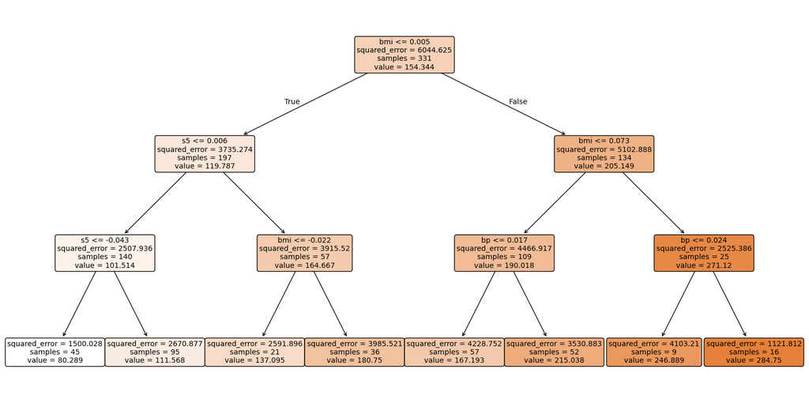

```
|--- bmi <= 0.01
|   |--- s5 <= 0.01
|   |   |--- s5 <= -0.04
|   |   |   |--- value: [80.29]
|   |   |--- s5 >  -0.04
|   |   |   |--- value: [111.57]
|   |--- s5 >  0.01
|   |   |--- bmi <= -0.02
|   |   |   |--- value: [137.10]
|   |   |--- bmi >  -0.02
|   |   |   |--- value: [180.75]
|--- bmi >  0.01
|   |--- bmi <= 0.07
|   |   |--- bp <= 0.02
|   |   |   |--- value: [167.19]
|   |   |--- bp >  0.02
|   |   |   |--- value: [215.04]
|   |--- bmi >  0.07
|   |   |--- bp <= 0.02
|   |   |   |--- value: [246.89]
|   |   |--- bp >  0.02
|   |   |   |--- value: [284.75]
```

```python
from sklearn import tree
import matplotlib.pyplot as plt

plt.figure(figsize=(20, 10))
tree.plot_tree(best_tree_model, feature_names=features, filled=True, rounded=True, max_depth=3)
plt.show()

text_representation = tree.export_text(best_tree_model, feature_names=features)
print(text_representation)
```

### 3.2.4 - 12. Calculate the expected diabetes progression for a BMI value

```python
bmi_value = 0.05
bp_value = 0.03
s5_value = 0.02

input_features = [[bmi_value, bp_value, s5_value]]

# Make the prediction with the trained model
predicted_diabetes_progression = best_tree_model.predict(input_features)

print(f'The expected progression of diabetes for a BMI of {bmi_value} is: {predicted_diabetes_progression[0]:.2f}')
```

```
The expected progression of diabetes for a BMI of 0.05 is: 215.04
```

#### 3.2.5 - 13. Trainable parameters

```python
# Get the number of leaves and depth of the best model
num_leaves = best_tree_model.get_n_leaves()
tree_depth = best_tree_model.get_depth()

print(f'Number of leaves (terminal nodes) of the tree: {num_leaves}')
print(f'Tree depth: {tree_depth}')
```

[output not shown]

### Conclusion

- Of the two decision tree models evaluated, both models show the same performance.
- The performance is moderate since its R2(0.36) is less than 50%, and its capacity to explain variability is moderate. Likewise, its MAE(42.53) and MAPE(42.77) values are similar.
- It is suggested to continue evaluating to find a better prediction.

## 3.3. Two kNNs

#### Two kNNs with range (1,21)

```python
from sklearn.neighbors import KNeighborsRegressor

results = []

best_k = None
best_r2_val = float('-inf')

for k in range(1, 21):
    model_knn = KNeighborsRegressor(n_neighbors=k)
    model_knn.fit(X_train[features], y_train)

    y_pred_val = model_knn.predict(X_val[features])
    r2_val = r2_score(y_val, y_pred_val)

    if r2_val > best_r2_val:
        best_r2_val = r2_val
        best_k = k

# Train the model with the best number of neighbors
best_knn_model = KNeighborsRegressor(n_neighbors=best_k)
best_knn_model.fit(X_train[features], y_train)

# Evaluate the model with the validation set
y_pred_val_best = best_knn_model.predict(X_val[features])
r2_val_best = r2_score(y_val, y_pred_val_best)
mae_val_best = mean_absolute_error(y_val, y_pred_val_best)
mape_val_best = (abs((y_val - y_pred_val_best) / y_val)).mean() * 100

results.append({'Best number of neighbors': best_k, 'Set': 'Validation', 'Range': '(1,21)','R2': r2_val_best, 'MAE': mae_val_best, 'MAPE': mape_val_best})

results_df = pd.DataFrame(results)
display(results_df)
```

[output not shown]

#### Two kNNs with range (1,31)

```python
from sklearn.neighbors import KNeighborsRegressor

best_k = None
best_r2_val = float('-inf')

for k in range(1, 31):
    model_knn = KNeighborsRegressor(n_neighbors=k)
    model_knn.fit(X_train[features], y_train)

    y_pred_val = model_knn.predict(X_val[features])
    r2_val = r2_score(y_val, y_pred_val)

    if r2_val > best_r2_val:
        best_r2_val = r2_val
        best_k = k

# Train the model with the best number of neighbors
best_knn_model = KNeighborsRegressor(n_neighbors=best_k)
best_knn_model.fit(X_train[features], y_train)

# Evaluate the model with the validation set
y_pred_val_best = best_knn_model.predict(X_val[features])
r2_val_best = r2_score(y_val, y_pred_val_best)
mae_val_best = mean_absolute_error(y_val, y_pred_val_best)
mape_val_best = (abs((y_val - y_pred_val_best) / y_val)).mean() * 100

results.append({'Best number of neighbors': best_k, 'Set': 'Validatiom', 'Range': '(1,31)','R2': r2_val_best, 'MAE': mae_val_best, 'MAPE': mape_val_best})

results_df = pd.DataFrame(results)
display(results_df)
```

[output not shown]

### 3.3.3 - 9. Run the chosen model on the test set and provide results (R-Squared, MAPE, MAE)

```python
# Evaluate the model on the test set
y_pred_test = best_knn_model.predict(X_test[features])
r2_test = r2_score(y_test, y_pred_test)
mae_test = mean_absolute_error(y_test, y_pred_test)
mape_test = (abs((y_test - y_pred_test) / y_test)).mean() * 100

print(f'Best number of neighbors: {best_k}, R2: {r2_test}, MAE: {mae_test}, MAPE: {mape_test}')

results.append({'Best number of neighborss': best_k,  'Set': 'Test', 'Range': '(1,31)', 'R2': r2_test, 'MAE': mae_test, 'MAPE': mape_test})
results_df = pd.DataFrame(results)
display(results_df)
```

[output not shown]

[output not shown]

### 3.3.4 - 11. Write down the equation of the best model

#### 3.3.4 - 12. Calculate the expected diabetes progression for a BMI value

```python
import numpy as np

bmi_value = 0.05
bp_value = 0.03
s5_value = 0.02

input_features = np.array([[bmi_value, bp_value, s5_value]])

# Predicting the expected progression of diabetes with the KNN model
expected_progression = best_knn_model.predict(input_features)

print(f"The expected progression of diabetes for a BMI of {bmi_value} is: {expected_progression[0]:.2f}")
```

```
The expected progression of diabetes for a BMI of 0.05 is: 194.00
```

#### 3.2.5 - 13. Trainable parameters

The KNN model has no traditional "trainable parameters". Instead of tuning coefficients, KNN simply stores the training data and, during prediction, calculates the distance between the test points and the training points to identify the "k" nearest neighbors.

## FINAL CONCLUSION

- Of all the models evaluated, the best model for prediction is the polynomial multivariate model with the variables [bmi, bp, s5] since its R2(0.5037) is greater than 50% (it has a greater capacity to explain variability) and its MAE(37.44) and MAPE(37.38%) values. - The models that continue are the kNNs model, the decision tree model continues. At the end is the linear polynomial regression model.